# MSDS DSE5002 Project 1

James Mahar

due 2024-11-24

#Summary of analysis of r_project_data_csv Chrome dataset

#Load “r_project_data_csv Chrome

```r
#Reference:
#From "Module 02 Lab 01"
#infile="/Users/jamesmahar/Desktop/MSDSDSE5002/Mod2/PP/sales csv Chrome.csv"

#sales_df=read.csv(infile)

infile = "/Users/jamesmahar/Desktop/MSDSDSE5002/Project 1/r project data csv Chrome.csv"

rproject1 = read_csv(infile)
```

```
## ──────────────────────────────────────────────────────── Delimiter: "," chr
## (7): experience_level, employment_type, job_title, salary_currency, empl... dbl
## (5): ...1, work_year, salary, salary_in_usd, remote_ratio
```

#Study dataframe structure

```r
str(rproject1)
```

```
## spc_tbl_ [607 × 12] (S3: spec_tbl_df/tbl_df/tbl/data.frame)
##  $ ...1              : num [1:607] 0 1 2 3 4 5 6 7 8 9 ...
##  $ work_year         : num [1:607] 2020 2020 2020 2020 2020 2020 2020 2020 2020 2020 ...
##  $ experience_level  : chr [1:607] "MI" "SE" "SE" "MI" ...
##  $ employment_type   : chr [1:607] "FT" "FT" "FT" "FT" ...
##  $ job_title         : chr [1:607] "Data Scientist" "Machine Learning Scientist" "Big Data Engineer" "Product Data Analyst" ...
##  $ salary            : num [1:607] 70000 260000 85000 20000 150000 72000 190000 11000000 135000 125000 ...
##  $ salary_currency   : chr [1:607] "EUR" "USD" "GBP" "USD" ...
##  $ salary_in_usd     : num [1:607] 79833 260000 109024 20000 150000 ...
##  $ employee_residence: chr [1:607] "DE" "JP" "GB" "HN" ...
##  $ remote_ratio      : num [1:607] 0 0 50 0 50 100 100 50 100 50 ...
##  $ company_location  : chr [1:607] "DE" "JP" "GB" "HN" ...
##  $ company_size      : chr [1:607] "L" "S" "M" "S" ...
##  - attr(*, "spec")=
##   .. cols(
##   ..   ...1 = col_double(),
##   ..   work_year = col_double(),
##   ..   experience_level = col_character(),
##   ..   employment_type = col_character(),
##   ..   job_title = col_character(),
##   ..   salary = col_double(),
##   ..   salary_currency = col_character(),
##   ..   salary_in_usd = col_double(),
##   ..   employee_residence = col_character(),
##   ..   remote_ratio = col_double(),
##   ..   company_location = col_character(),
##   ..   company_size = col_character()
##   .. )
##  - attr(*, "problems")=<externalptr>
```

```r
unique(rproject1$experience_level)
```

```
## [1] "MI" "SE" "EN" "EX"
```

```r
unique(rproject1$company_location)
```

```
##  [1] "DE" "JP" "GB" "HN" "US" "HU" "NZ" "FR" "IN" "PK" "CN" "GR" "AE" "NL" "MX"
## [16] "CA" "AT" "NG" "ES" "PT" "DK" "IT" "HR" "LU" "PL" "SG" "RO" "IQ" "BR" "BE"
## [31] "UA" "IL" "RU" "MT" "CL" "IR" "CO" "MD" "KE" "SI" "CH" "VN" "AS" "TR" "CZ"
## [46] "DZ" "EE" "MY" "AU" "IE"
```

```r
unique(rproject1$company_size)
```

```
## [1] "L" "S" "M"
```

```r
head(rproject1)
```

```
## # A tibble: 6 × 12
##    ...1 work_year experience_level employment_type job_title              salary
##   <dbl>     <dbl> <chr>            <chr>           <chr>                   <dbl>
## 1     0      2020 MI               FT              Data Scientist          70000
## 2     1      2020 SE               FT              Machine Learning Scie… 260000
## 3     2      2020 SE               FT              Big Data Engineer       85000
## 4     3      2020 MI               FT              Product Data Analyst    20000
## 5     4      2020 SE               FT              Machine Learning Engi… 150000
## 6     5      2020 EN               FT              Data Analyst            72000
## # ℹ 6 more variables: salary_currency <chr>, salary_in_usd <dbl>,
## #   employee_residence <chr>, remote_ratio <dbl>, company_location <chr>,
## #   company_size <chr>
```

```r
tail(rproject1)
```

```
## # A tibble: 6 × 12
##    ...1 work_year experience_level employment_type job_title     salary
##   <dbl>     <dbl> <chr>            <chr>           <chr>          <dbl>
## 1   601      2022 EN               FT              Data Analyst   52000
## 2   602      2022 SE               FT              Data Engineer 154000
## 3   603      2022 SE               FT              Data Engineer 126000
## 4   604      2022 SE               FT              Data Analyst  129000
## 5   605      2022 SE               FT              Data Analyst  150000
## 6   606      2022 MI               FT              AI Scientist  200000
## # ℹ 6 more variables: salary_currency <chr>, salary_in_usd <dbl>,
## #   employee_residence <chr>, remote_ratio <dbl>, company_location <chr>,
## #   company_size <chr>
```

```r
#summary(rproject1)
#view(rproject1)
```

Summary of steps to establish data for ppt slides:

After reviewing the dataframe in Excel: Consider to tidy data: 1. Drop the “salary” and “salary_currency” columns 2. DONE Assume we are in US. 3. Add Ranking column 4. The CEO needs to know what a team looks like. Thus, we must resolve/simplify and define the titles so that the CEO clearly knows what each is responsible for. Then create graphics. 5. Rename experience level codes: a. EN Entry-level b. MI Mid-level c. SE Senior-level d. EX Executive-level 6. DONE Need to resolve what constitutes a team count the number of different titles and classify them in the team file. 7. Other tidy steps TBD

```r
#Show unique job_titles
#FYI: my Excel file only shows 333 to 350 of 607 entries, 12 total columns

#Referencce: https://www.geeksforgeeks.org/r-dplyr-distinct-function/

#count(rproject1$job_title)
unique(rproject1$job_title)
```

```
##  [1] "Data Scientist"
##  [2] "Machine Learning Scientist"
##  [3] "Big Data Engineer"
##  [4] "Product Data Analyst"
##  [5] "Machine Learning Engineer"
##  [6] "Data Analyst"
##  [7] "Lead Data Scientist"
##  [8] "Business Data Analyst"
##  [9] "Lead Data Engineer"
## [10] "Lead Data Analyst"
## [11] "Data Engineer"
## [12] "Data Science Consultant"
## [13] "BI Data Analyst"
## [14] "Director of Data Science"
## [15] "Research Scientist"
```

[output cut: 35 more lines]

```r
#some of the title names are:

#DS_titles <- c("Data_Engineer",
  #"Data_Scientist",
  #"Data_Analyst",
  #"Machine_Learning_Engineer",
  #"Data_Architect",
  #"Data_Science_Manager",
  #"Head_of_Data_Science",
  #"Analytics_Engineer",
  #"Lead_Data_Engineer",
  #"Machine_Learning_Scientist",
  #"Data_Analytics_Manager",
  #"AI_Scientist",
  ##"Research_Scientist",
  #"ETL_Developer",
  #"Staff_Data_Scientist",
  #"Head_of_Data",
  #"Head_of_Machine_Learning",
  #"Data_Science-Consultant",
  #"Data_Science_Engineer",
  #"Business_Data_Analyst",
  #"Computer_Vision_Engineer")
#DS_titles
```

Visuals:

Visuals suggestions:

#1. Bar Chart for Salary by Role/Experience/Location o This chart will have clear, differentiated colors for each role. o X-axis (Experience): Junior, Mid, Senior o Y-axis (Salary): In USD #2. NOT DONE Gantt Chart or Timeline for Hiring o Each role can be plotted along the timeline with bars for each hiring milestone. o Show months or quarters on the x-axis and roles on the y-axis. o Color-code bars for remote vs non-remote hires. #3. NOT DONE Line Graph for Salary Costs o Show the cumulative salary cost over time as the team grows. o Plot individual role costs and total salary expenses. #4. LISTED Infographic for Key Insights o Icons to represent milestones: dollar signs, people, timeframes. o Use simple arrows or circular diagrams to show progress and forecast.

I will use the following typical titles in a Data Science(DS) team: • Data Scientist first per CEO • Data Engineer • Machine Learning Engineer • Data Analyst • Data Science Manager • Chief Data Officer (CDO)

Analysis names: • Key Team Roles (Responsibilities) “job_title”: o Entry-Level Data Scientist (Analytical, data processing) “Data Scientist” o Mid-Level Data Scientist (Modeling, feature engineering) “Principal Data Scientist” o Senior Data Scientist (Advanced analytics, leadership) “Lead Data Scientist” o Data Engineer (Infrastructure, pipelines) “Data Engineer” o Machine Learning Engineer (Model deployment, optimization) “Machine Learning Engineer” o Data Science Manager (Team leadership, project oversight) “Data Engineering Manager” o Head of Data Science (Strategic vision, cross-functional leadership) “Head of Data Science”

Column names for DS_team dataframe:

Research: FYI: Costs of a team build are staggered over a year timeframe.

Role Q1 Q2 Q3 Q4 Junior Data Scientist”Data Scientist” X  
Data Engineer “Data Engineer” X  
Senior Data Scientist “Lead Data Scientist” X  
Junior Data Analyst “Data Analyst” X  
ML Engineer “Machine Learning Engineer” X Data Science Manager “Data Engineering Manager” X Senior Data Engineer “Lead Data Engineer” X CDO “Head of Data Science” X Total cost: ~$290k ~$240k ~$300k ~$430k

Data wrangling:

```r
#load libraries
library(ggplot2)
library(tidyverse)
library(ggthemes)

#Reference:
#For colorblind plots add: library(ggthemes) and …+theme_igray()+scale_colour_colorblind()…

#Steps:

#Wrangle then Plot

#Wrangle:
#Reduce the number of titles in a DS_team dataframe,
#Rename columns and entries for clarity after plotting
#Add min and max salaries for experience levels

#Reference: https://dplyr.tidyverse.org/reference/select.html
#starwars %>% select(homeworld, height, mass)


#DS_team <- filter(rproject1, job_title == c("Data Scientist", "Principal Data Scientist", "Lead Data Scientist", "Data Engineer", "Machine Learning Engineer", "Data Engineering Manager", "Head of Data Science"))

#DS_team <- filter(rproject1, job_title == c("Principal Data Scientist","Data Scientist","Head of Data Science","Data Engineer", "Machine Learning Engineer"))
#DS_team


#Select only DS team titles in job_title column

DS_team <- filter(rproject1, job_title %in% c("Principal Data Scientist","Data Scientist","Head of Data Science","Data Engineer", "Machine Learning Engineer"))
DS_team
```

```
## # A tibble: 327 × 12
##     ...1 work_year experience_level employment_type job_title             salary
##    <dbl>     <dbl> <chr>            <chr>           <chr>                  <dbl>
##  1     0      2020 MI               FT              Data Scientist        7   e4
##  2     4      2020 SE               FT              Machine Learning Eng… 1.5 e5
##  3     7      2020 MI               FT              Data Scientist        1.10e7
##  4    10      2020 EN               FT              Data Scientist        4.50e4
##  5    11      2020 MI               FT              Data Scientist        3   e6
##  6    12      2020 EN               FT              Data Scientist        3.5 e4
##  7    16      2020 EN               FT              Data Engineer         4.45e6
##  8    20      2020 MI               FT              Machine Learning Eng… 2.99e5
##  9    22      2020 SE               FT              Data Engineer         4.20e4
## 10    27      2020 SE               FT              Data Engineer         7.20e5
## # ℹ 317 more rows
## # ℹ 6 more variables: salary_currency <chr>, salary_in_usd <dbl>,
## #   employee_residence <chr>, remote_ratio <dbl>, company_location <chr>,
## #   company_size <chr>
```

```r
#FYI: Pivot from long to wide to see team title spread by experience

#Reference: https://www.geeksforgeeks.org/reshape-dataframe-from-long-to-wide-format-in-r/

rproject1_wide <-  spread(DS_team,
                         key=experience_level,
                         value=salary_in_usd)
rproject1_wide
```

```
## # A tibble: 327 × 14
##     ...1 work_year employment_type job_title              salary salary_currency
##    <dbl>     <dbl> <chr>           <chr>                   <dbl> <chr>
##  1     0      2020 FT              Data Scientist         7   e4 EUR
##  2     4      2020 FT              Machine Learning Engi… 1.5 e5 USD
##  3     7      2020 FT              Data Scientist         1.10e7 HUF
##  4    10      2020 FT              Data Scientist         4.50e4 EUR
##  5    11      2020 FT              Data Scientist         3   e6 INR
##  6    12      2020 FT              Data Scientist         3.5 e4 EUR
##  7    16      2020 FT              Data Engineer          4.45e6 JPY
##  8    20      2020 FT              Machine Learning Engi… 2.99e5 CNY
##  9    22      2020 FT              Data Engineer          4.20e4 EUR
## 10    27      2020 FT              Data Engineer          7.20e5 MXN
## # ℹ 317 more rows
## # ℹ 8 more variables: employee_residence <chr>, remote_ratio <dbl>,
## #   company_location <chr>, company_size <chr>, EN <dbl>, EX <dbl>, MI <dbl>,
## #   SE <dbl>
```

```r
sal_plot_table <- DS_team %>% group_by(job_title, experience_level) %>% summarize(min = min(salary_in_usd/1000), mean = mean(salary_in_usd/1000), max= max(salary_in_usd/1000), )
sal_plot_table
```

```
## # A tibble: 15 × 5
## # Groups:   job_title [5]
##    job_title                 experience_level    min  mean   max
##    <chr>                     <chr>             <dbl> <dbl> <dbl>
##  1 Data Engineer             EN                21.6   58.9  120
##  2 Data Engineer             EX               200    246.   324
##  3 Data Engineer             MI                 4     86.0  207.
##  4 Data Engineer             SE                25    137.   244.
##  5 Data Scientist            EN                 4     55.3  105
##  6 Data Scientist            MI                 2.86  82.0  200
##  7 Data Scientist            SE                20.2  153.   412
##  8 Head of Data Science      EX                85    159.   224
##  9 Head of Data Science      MI               110    110    110
## 10 Machine Learning Engineer EN                20     87.0  250
## 11 Machine Learning Engineer MI                24.8   74.5  124.
## 12 Machine Learning Engineer SE                24.3  131.   220
## 13 Principal Data Scientist  EX               416    416    416
## 14 Principal Data Scientist  MI               151    151    151
## 15 Principal Data Scientist  SE               148.   188.   235
```

Ready to plot barcharts and boxplots for salary by role/experience/location

Reference: From Pair_Programming_Long_data_Module3

ggplot(df_phones_long,aes(x=year, y=phones,fill=region))+geom_bar(stat=“identity”,position=“dodge”)

Reference: plotting: https://sscc.wisc.edu/sscc/pubs/dvr/two-variables.html

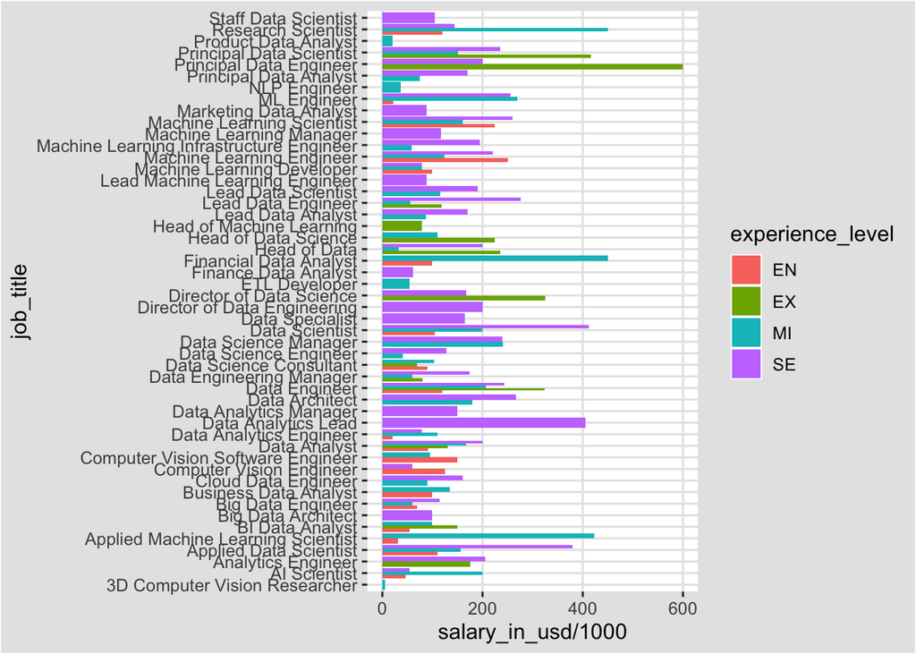

```r
#Barplot of all job_titles vs salary_in_usd by experience_level
#This works:
ggplot(rproject1,aes(x=job_title, y=salary_in_usd/1000,fill=experience_level))+geom_bar(stat="identity",position="dodge")+coord_flip()+theme_igray()+scale_colour_colorblind()
```

Very busy. I must limit barchart to DS_team titles. Option: Reorder barplot bars from low to high place a - sign in front of “value”, no - for high to low.

Reference: https://stackoverflow.com/questions/25664007/reorder-bars-in-geom-bar-ggplot2-by-value

Example: ggplot(corr.m, aes(x = reorder(miRNA, -value), y = value, fill = variable)) + geom_bar(stat = “identity”)

Group by and add salary: min, max, and mean columns. Example: sal_plot_table <- DS_team %>% group_by(job_title, experience_level) %>% summarize(mean = mean(salary_in_usd/1000), max= max(salary_in_usd/1000), min = min(salary_in_usd/1000))

```r
sal_plot_table <- DS_team %>% group_by(job_title, experience_level,company_size,company_location,remote_ratio,work_year) %>% summarize(mean = mean(salary_in_usd/1000), max= max(salary_in_usd/1000), min = min(salary_in_usd/1000))
```

[output not shown]

```r
sal_plot_table
```

```
## # A tibble: 168 × 9
## # Groups:   job_title, experience_level, company_size, company_location,
## #   remote_ratio [144]
##    job_title     experience_level company_size company_location remote_ratio
##    <chr>         <chr>            <chr>        <chr>                   <dbl>
##  1 Data Engineer EN               L            DE                        100
##  2 Data Engineer EN               L            IN                        100
##  3 Data Engineer EN               L            US                        100
##  4 Data Engineer EN               M            DE                         50
##  5 Data Engineer EN               M            DE                        100
##  6 Data Engineer EN               M            GB                        100
##  7 Data Engineer EN               M            IN                         50
##  8 Data Engineer EN               M            US                        100
##  9 Data Engineer EN               S            JP                        100
## 10 Data Engineer EN               S            US                        100
## # ℹ 158 more rows
## # ℹ 4 more variables: work_year <dbl>, mean <dbl>, max <dbl>, min <dbl>
```

Barplot of Descending or horizontal barchart of min salaries of DS_team titles

How to create a horizontal barchart:

Reference: https://www.datanovia.com/en/blog/how-to-create-a-ggplot-horizontal-bar-chart/

Add “+ coord_flip() to show a horizontal bargraph The Reference for the horizontal bargraph suggested add: theme_set(theme_bw())

Showing data values on stacked bar chart in ggplot2 in R:

Reference: https://www.geeksforgeeks.org/showing-data-values-on-stacked-bar-chart-in-ggplot2-in-r/

geom_text(size = 3, position = position_stack(vjust = 0.5),colour = “white”)

The size represents the size of the font that will appear on the plot and position_stack() will automatically add values to the plot at their respective positions.

Mean salary barplot of ??? not needed??? ggplot(sal_plot_table, aes(x=reorder(job_title,mean),y=mean,fill=experience_level))+geom_bar(stat=“identity”,position=“dodge”)+coord_flip()+theme_igray()+scale_colour_colorblind()

#Horizontal barplot of salarie values of all job_titles and experience_level using +coord_flip() repeated here:

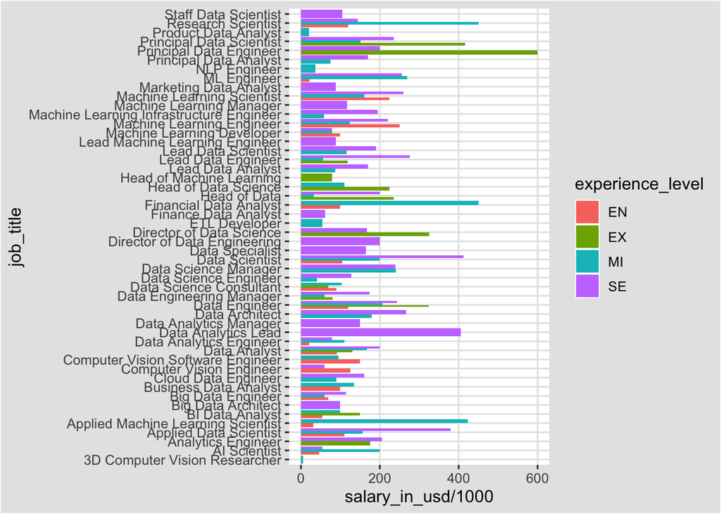

```r
#This works
#Horizontal barplot of mean salary of all job_titles and experience_level.

ggplot(rproject1,aes(x=job_title, y=salary_in_usd/1000,fill=experience_level))+geom_bar(stat="identity",position="dodge")+coord_flip()+theme_igray()+scale_colour_colorblind()
```

This is too busy; more wrangling needed. I will limit the number of titles to the following to get a better graphic.

```r
unique(DS_team$job_title)
```

```
## [1] "Data Scientist"            "Machine Learning Engineer"
## [3] "Data Engineer"             "Principal Data Scientist"
## [5] "Head of Data Science"
```

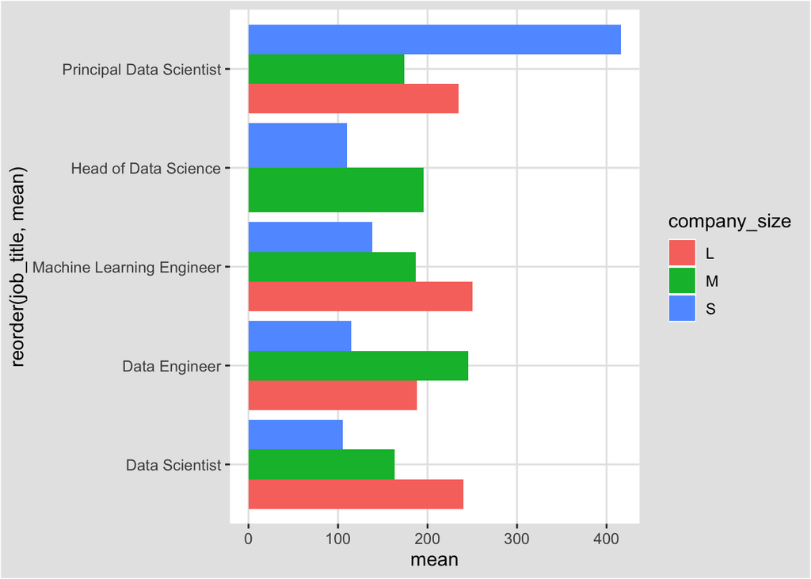

```r
#This works
#Horizontal barplot of mean salary of DS_team job_titles and company_size.
ggplot(sal_plot_table, aes(x=reorder(job_title, mean), y = mean, fill=company_size))+coord_flip()+geom_bar(stat="identity",position="dodge")+theme_igray()+scale_colour_colorblind()
```

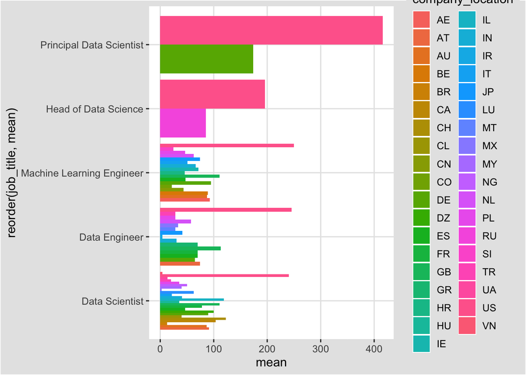

```r
#This works
#Horizontal barplot of mean salary of DS_team job_titles and company_location.

ggplot(sal_plot_table, aes(x=reorder(job_title, mean), y = mean, fill=company_location))+coord_flip()+geom_bar(stat="identity",position="dodge")+theme_igray()+scale_colour_colorblind()
```

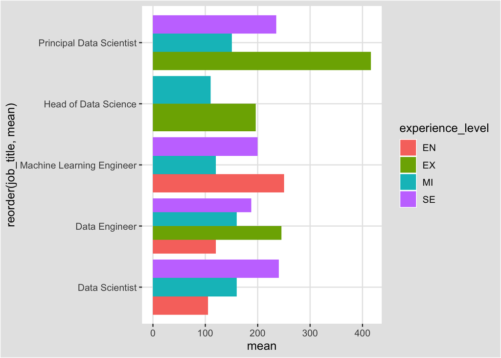

```r
#This works
#Horizontal barplot of mean salary of DS_team job_titles and experience_level.

ggplot(sal_plot_table, aes(x=reorder(job_title, mean), y = mean, fill=experience_level))+coord_flip()+geom_bar(stat="identity",position="dodge")+theme_igray()+scale_colour_colorblind()
```

Horizontal boxplot of mean salary of job_title v experience_level

Reference: ggplot(iris_new_long,aes(x= Species, y=dimension, color=flowerpart))+geom_boxplot() ggplot(sal_plot_table, aes(x=reorder(job_title, mean), y = mean, fill=company_location))+coord_flip()+geom_bar(stat=“identity”,position=“dodge”)+theme_igray()+scale_colour_colorblind()

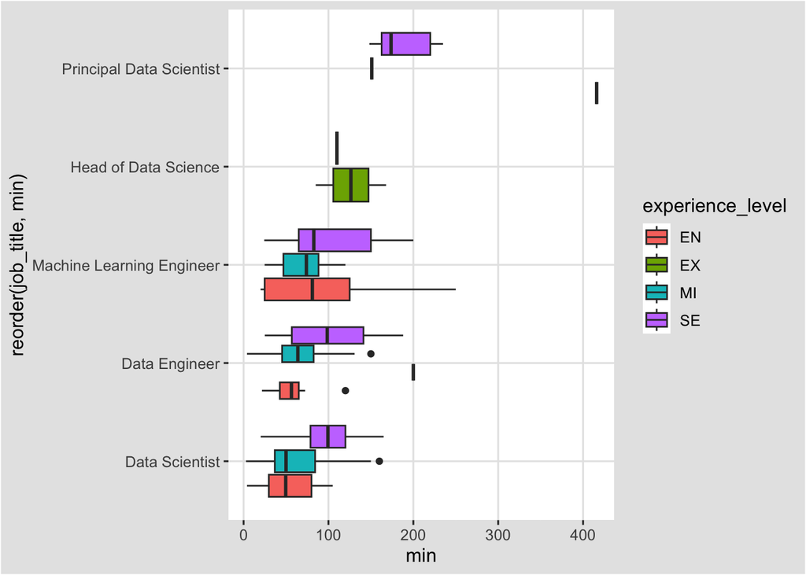

```r
#This works
#Horizontal boxplots of min, mean, max salary of DS_team job_titles and experience_level.
ggplot(sal_plot_table, aes(x=reorder(job_title, min), y = min,fill=experience_level))+coord_flip()+geom_boxplot()+theme_igray()+scale_colour_colorblind()
```

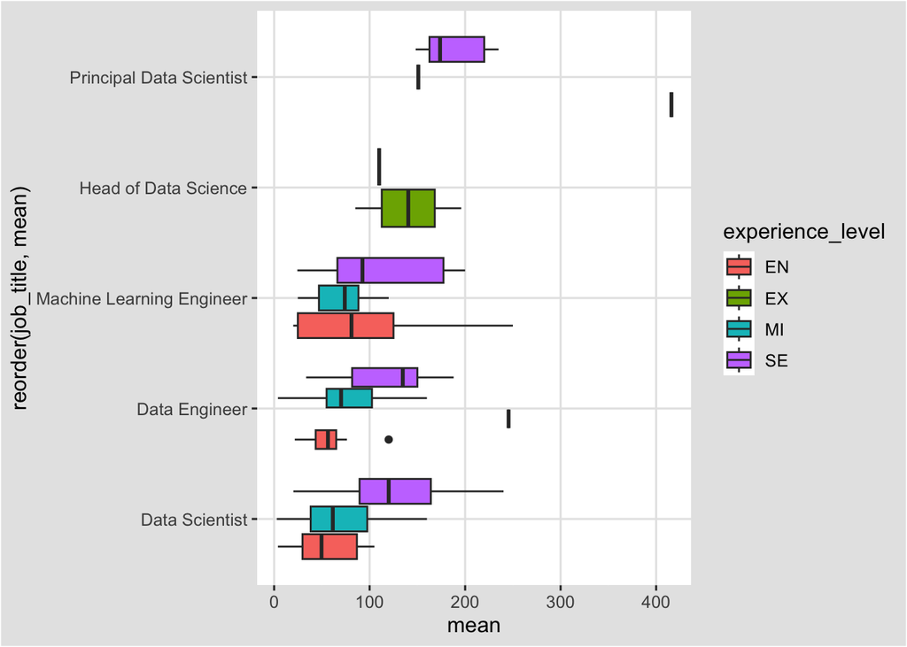

```r
ggplot(sal_plot_table, aes(x=reorder(job_title, mean), y = mean,fill=experience_level))+coord_flip()+geom_boxplot()+theme_igray()+scale_colour_colorblind()
```

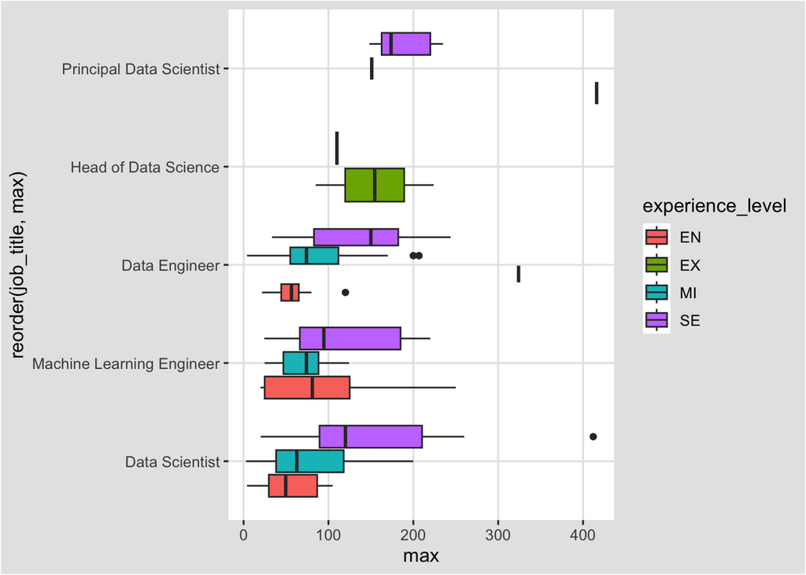

```r
ggplot(sal_plot_table, aes(x=reorder(job_title, max), y = max,fill=experience_level))+coord_flip()+geom_boxplot()+theme_igray()+scale_colour_colorblind()
```

Notes:

Sort each salary_in_usd descending for each job_title then select the top number of values and the lower values

Reference: https://www.geeksforgeeks.org/select-top-n-highest-values-by-group-in-r/

Step 1: Sort salary_in_usd column descending data_sorted_des <- DS_team[order(rproject1$salary_in_usd, decreasing = TRUE), ]

data_sorted_des <- sal_plot_table[order(sal_plot_table$max, decreasing = TRUE), ]

Step 2: Select top values from each job_title from sort descending to get top. data_mod_top <- Reduce(rbind,  
by(data_sorted_des, data_sorted_des[“job_title”], head, n = 10)) data_mod_top

Step 4: Select top values from each job_title from sort ascending to get bottom. data_mod_bot <- Reduce(rbind, by(data_sorted_asc, data_sorted_asc[“job_title”], tail, n = 10)) data_mod_bot

Step 5: Boxplot salary_in_usd/1000 bottom 10 and top 10

Reference:?

ggplot(data_mod,aes(x=job_title, y=salary_in_usd/1000, color=experience_level))+geom_boxplot()+coord_flip()+theme_igray()+scale_colour_colorblind()

This works ggplot(data_mod_bot,aes(x=sal_plot_table, y=mean, color=experience_level)+coord_flip()+geom_boxplot()+theme_igray()+scale_colour_colorblind())

This works ggplot(data_mod_top,aes(x=al_plot_table, y=mean, color=experience_level)+coord_flip()+geom_boxplot()+theme_igray()+scale_colour_colorblind())

How do I plot both min and max for each title?

Reference: https://stackoverflow.com/questions/29916770/geom-bar-from-min-to-max-data-value

ggplot(datap1) +

geom_segment(aes(x=estacion, xend=estacion, y=Promedio_diario, #yend=Maximo_horario), size=3, color=“orange”) +geom_hline(yintercept=mean((datap1$Maximo_horario + datap1$Promedio_diario)/2, na.rm=TRUE), color=“red”) + theme_bw() + theme(axis.text.x=element_text(angle=90))

ggplot(datap1) + geom_segment(aes(x=estacion, xend=estacion, y=Promedio_diario, yend=Maximo_horario), size=3, color=“orange”) + geom_hline(yintercept=mean((datap1$Maximo_horario + datap1$Promedio_diario)/2, na.rm=TRUE), color=“red”) + theme_bw() + theme(axis.text.x=element_text(angle=90))

or

ggplot(datap1) + geom_linerange(aes(x=estacion, y=average, ymin=Promedio_diario, ymax=Maximo_horario), size=3, color=“orange”) + geom_hline(yintercept=mean((datap1$Maximo_horario + datap1$Promedio_diario)/2, na.rm=TRUE), color=“red”) + theme_bw() + theme(axis.text.x=element_text(angle=90))

Adding labels to the barplot-not used; here for reference. Reference: https://www.statology.org/ggplot-histogram-labels/ https://www.geeksforgeeks.org/how-to-add-labels-directly-in-ggplot2-in-r/

group_by() exp, location, title, summarize(mean, max)